# Testing affect regulation via computational modeling of real-time alcohol choices in daily life: Boundary Separation (B)

2026-04-06

# 1 About This Report

This report presents results for **Boundary Separation (B)** (B) across all four focal predictors: stress (binary), stress (state), negative affect (state), and positive affect (state).

For each predictor, the report is organized as follows:

- **Dimensionality reduction:** PCA and UMAP component composition tables, showing which raw variables load most strongly onto each component.
- **GLMM results (raw features):** Summary of results from GLMM model with raw variables.
- **Random forest results (raw features):** Summary of results from random forest model with raw variables.
- **Model comparison:** RMSE comparison table across all methods (GLMM, random forest, decision tree) and feature sets (raw, PCA, UMAP).

# 2 Stress Binary (stress_binary)

## 2.1 Dimensionality Reduction

- **PCA components (80% variance, max 5):** 5
- **UMAP components (matching PCA):** 5

### 2.1.1 PCA Component Composition (top 5 correlated variables)

**PC_1**

| Variable | Correlation |
| --- | --- |
| alc_exp_energeticYes | -0.576 |
| alc_exp_better_moodYes | -0.557 |
| alc_exp_sociableYes | -0.547 |
| alc_exp_buzzYes | -0.502 |
| alc_craving | -0.487 |

**PC_2**

| Variable | Correlation |
| --- | --- |
| alc_exp_injuryYes | -0.596 |
| alc_exp_be_rudeYes | -0.594 |
| alc_exp_embarrassedYes | -0.579 |
| alc_exp_nauseous_vomitYes | -0.491 |
| alc_exp_hangoverYes | -0.468 |

**PC_3**

| Variable | Correlation |
| --- | --- |
| locationschool_work | 0.591 |
| alc_today | -0.578 |
| alc_cuenone | 0.568 |
| time_of_dayevening | -0.476 |
| locationhome | -0.458 |

**PC_4**

| Variable | Correlation |
| --- | --- |
| soft_yday | 0.699 |
| soft_today | 0.650 |
| soft_intend | 0.634 |
| soft_craving | 0.489 |
| alc_exp_embarrassedYes | -0.388 |

**PC_5**

| Variable | Correlation |
| --- | --- |
| locationhome | -0.632 |
| social_context_aloneYes | -0.560 |
| social_context_friend_roommateYes | 0.500 |
| social_context_strangerYes | 0.417 |
| locationsomeone_elses_home | 0.372 |

### 2.1.2 UMAP Component Composition (top 5 correlated variables)

**UMAP_1**

| Variable | Correlation |
| --- | --- |
| alc_exp_embarrassedYes | -0.301 |
| alc_exp_be_rudeYes | -0.298 |
| alc_craving | -0.235 |
| alc_intend | -0.190 |
| alc_mot_copingYes | -0.147 |

**UMAP_2**

| Variable | Correlation |
| --- | --- |
| alc_yday | 0.368 |
| soft_yday | -0.127 |
| alc_intend | 0.127 |
| alc_mot_enhanceYes | 0.113 |
| soft_today | -0.092 |

**UMAP_3**

| Variable | Correlation |
| --- | --- |
| alc_today | 0.425 |
| alc_yday | 0.419 |
| alc_intend | 0.206 |
| alc_cuenone | -0.194 |
| responsibilityYes | -0.134 |

**UMAP_4**

| Variable | Correlation |
| --- | --- |
| soft_yday | -0.792 |
| soft_today | -0.683 |
| soft_intend | -0.568 |
| soft_craving | -0.294 |
| alc_exp_be_rudeYes | -0.185 |

**UMAP_5**

| Variable | Correlation |
| --- | --- |
| alc_exp_injuryYes | 0.509 |
| alc_exp_embarrassedYes | 0.385 |
| alc_exp_be_rudeYes | 0.382 |
| alc_exp_nauseous_vomitYes | 0.356 |
| alc_exp_energeticYes | 0.231 |

## 2.2 GLMM Results

### 2.2.1 Raw Features

- **Optimal lambda:** 130 (index 8 of 21)
- **CV RMSE:** 0.3231

**Non-zero coefficients** (focal predictor terms highlighted):

| Term | Estimate | Category |
| --- | --- | --- |
| (Intercept) | 0.8329 | Intercept |
| stress_binary | 0.0012 | Focal predictor |
| alc_craving | -0.0165 | Covariate main effect |
| alc_exp_better_moodYes | -0.0124 | Covariate main effect |
| alc_mot_copingYes | -0.0090 | Covariate main effect |
| bored_state | -0.0054 | Covariate main effect |
| soft_today | 0.0036 | Covariate main effect |
| alc_mot_enhanceYes | -0.0025 | Covariate main effect |
| time_of_dayevening:stress_binary | -0.0806 | Interaction with focal predictor |
| locationhome:stress_binary | 0.0016 | Interaction with focal predictor |
| alc_exp_relaxedYes:stress_binary | 0.0009 | Interaction with focal predictor |
| soft_today:stress_binary | 0.0006 | Interaction with focal predictor |
| soft_yday:stress_binary | 0.0002 | Interaction with focal predictor |

- 85 coefficients penalized to zero.*

#### 2.2.1.1 Predicted vs. Observed

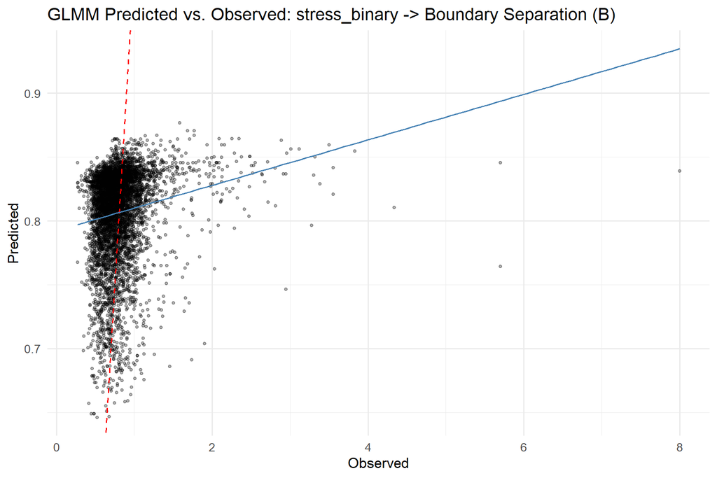

#### 2.2.1.2 Residual Diagnostics

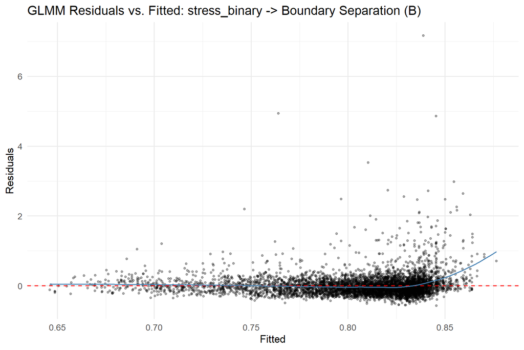

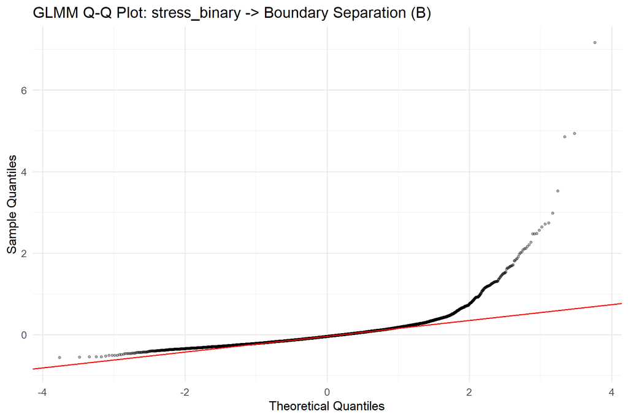

### 2.2.2 PCA Features

- **Optimal lambda:** 130 (index 8 of 21)
- **CV RMSE:** 0.3231

**Non-zero coefficients:**

| Term | Estimate |
| --- | --- |
| (Intercept) | 0.8071 |
| PC_1 | 0.0079 |
| PC_2 | -0.0245 |
| PC_2:stress_binary | 0.0001 |
| PC_5:stress_binary | 0.0144 |

- 7 coefficients penalized to zero.*

### 2.2.3 UMAP Features

- **Optimal lambda:** 30 (index 18 of 21)
- **CV RMSE:** 0.3224

**Non-zero coefficients:**

| Term | Estimate |
| --- | --- |
| (Intercept) | 0.8065 |
| UMAP_1 | -0.0167 |
| UMAP_4 | -0.0166 |
| UMAP_5 | -0.0080 |
| UMAP_1:stress_binary | 0.0019 |
| UMAP_2:stress_binary | 0.0017 |
| UMAP_4:stress_binary | 0.0002 |
| UMAP_5:stress_binary | 0.0053 |

- 4 coefficients penalized to zero.*

## 2.3 Random Forest Results (Raw)

### 2.3.1 Tuning Summary

- **mtry:** 13
- **min.node.size:** 4
- **sample.fraction:** 0.808
- **CV RMSE:** 0.2976

### 2.3.2 Variable Importance (Permutation)

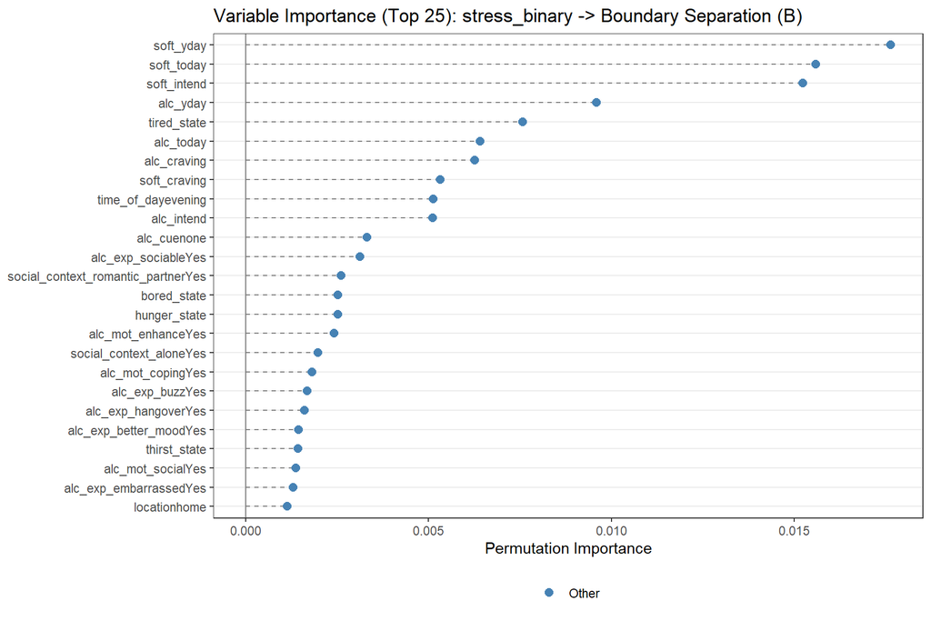

**Full importance ranking:**

| Variable | Importance |
| --- | --- |
| soft_yday | 0.017638 |
| soft_today | 0.015592 |
| soft_intend | 0.015241 |
| alc_yday | 0.009587 |
| tired_state | 0.007576 |
| alc_today | 0.006412 |
| alc_craving | 0.006255 |
| soft_craving | 0.005317 |
| time_of_dayevening | 0.005130 |
| alc_intend | 0.005115 |
| alc_cuenone | 0.003321 |
| alc_exp_sociableYes | 0.003116 |
| social_context_romantic_partnerYes | 0.002603 |
| bored_state | 0.002518 |
| hunger_state | 0.002515 |
| alc_mot_enhanceYes | 0.002419 |
| social_context_aloneYes | 0.001979 |
| alc_mot_copingYes | 0.001808 |
| alc_exp_buzzYes | 0.001672 |
| alc_exp_hangoverYes | 0.001611 |
| alc_exp_better_moodYes | 0.001446 |
| thirst_state | 0.001421 |
| alc_mot_socialYes | 0.001365 |
| alc_exp_embarrassedYes | 0.001295 |
| locationhome | 0.001129 |
| social_context_familyYes | 0.001021 |
| alc_exp_energeticYes | 0.000993 |
| alc_exp_be_rudeYes | 0.000841 |
| stress_binary | 0.000815 |
| responsibilityYes | 0.000533 |
| alc_exp_nauseous_vomitYes | 0.000400 |
| locationschool_work | 0.000349 |
| social_context_friend_roommateYes | 0.000209 |
| alc_exp_injuryYes | 0.000139 |
| day_of_weekMon | 0.000082 |
| locationother | 0.000055 |
| alc_cueindirectly_visible | 0.000049 |
| locationsomeone_elses_home | 0.000036 |
| locationoutdoors | 0.000036 |
| social_context_strangerYes | 0.000023 |
| social_context_otherYes | 0.000008 |
| locationrestaurant_cafe | 0.000002 |
| social_context_coworker_classmateYes | -0.000008 |
| day_of_weekThu | -0.000036 |
| alc_exp_relaxedYes | -0.000050 |
| day_of_weekSun | -0.000229 |
| day_of_weekTue | -0.000251 |
| day_of_weekWed | -0.000443 |
| day_of_weekSat | -0.000683 |

### 2.3.3 Partial Dependence Plots

PDP for the focal predictor and the top 5 most important non-interaction covariates.

#### 2.3.3.1 Focal Predictor: stress_binary

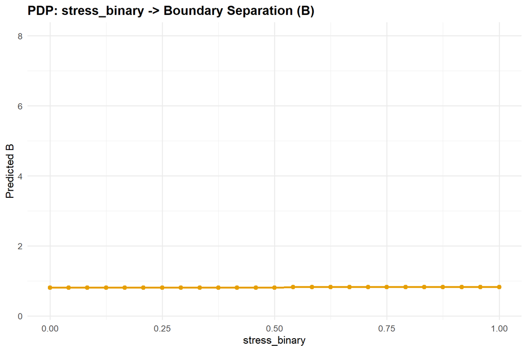

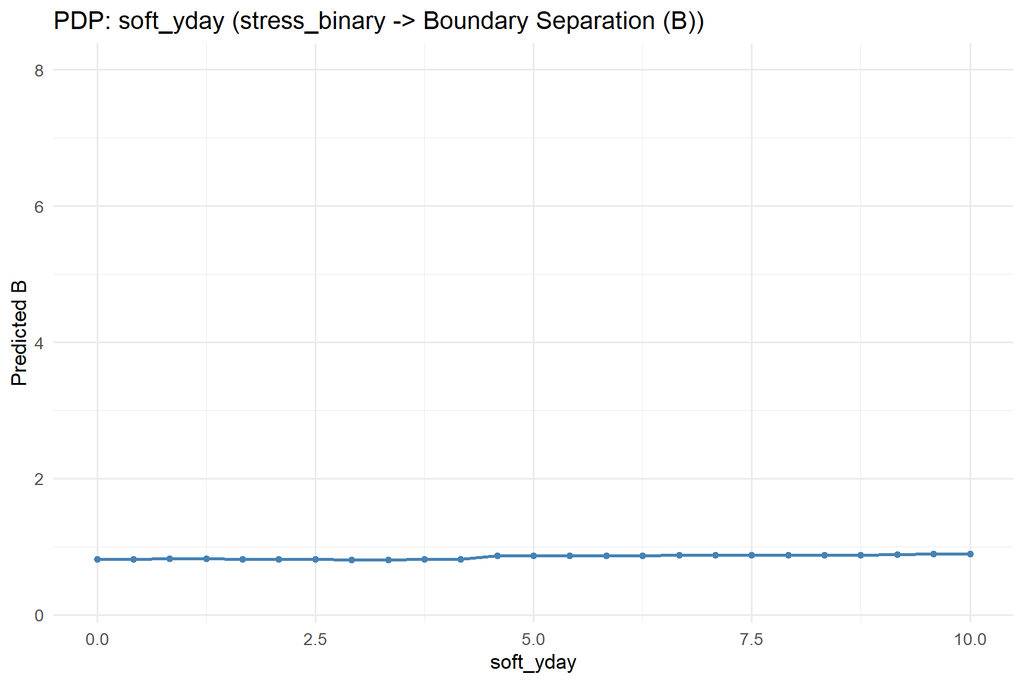

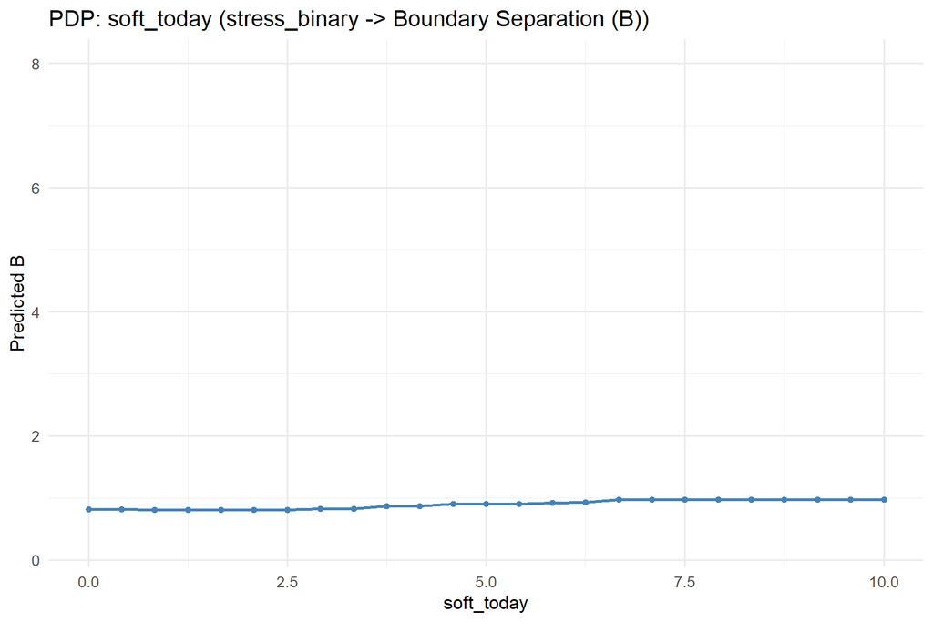

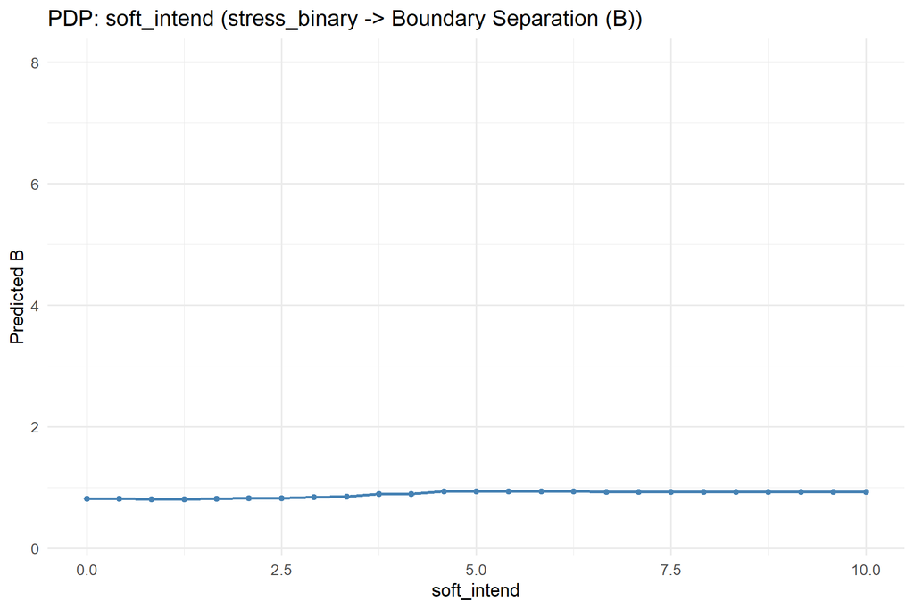

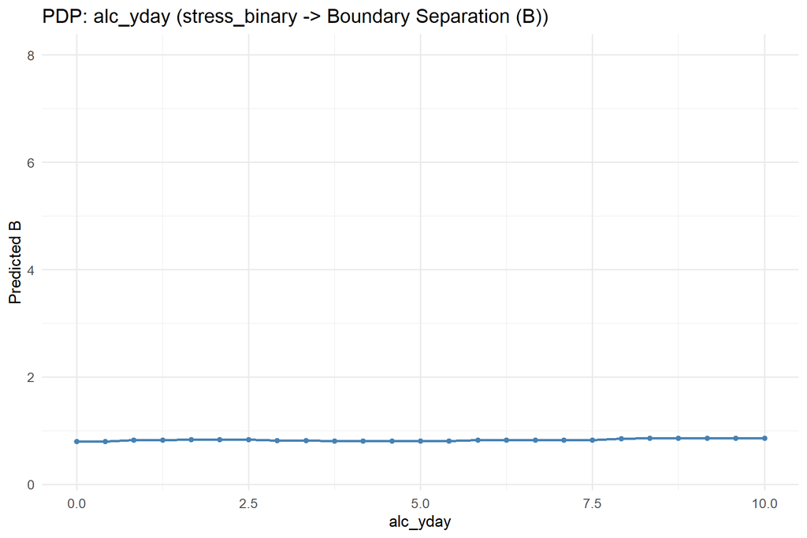

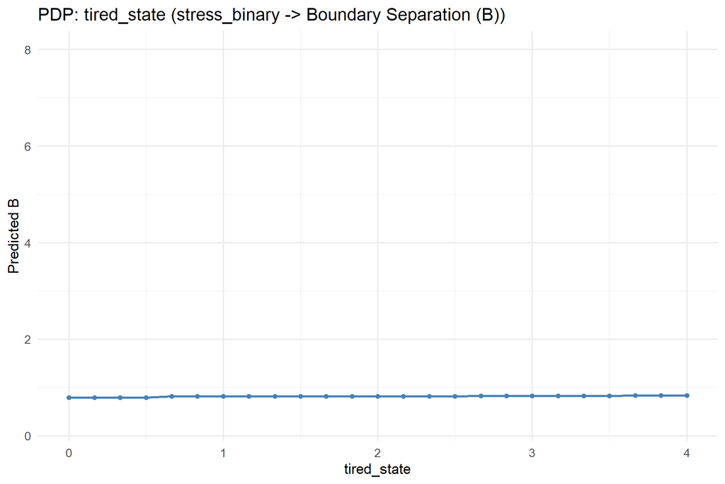

### 2.3.4 Predicted vs. Observed

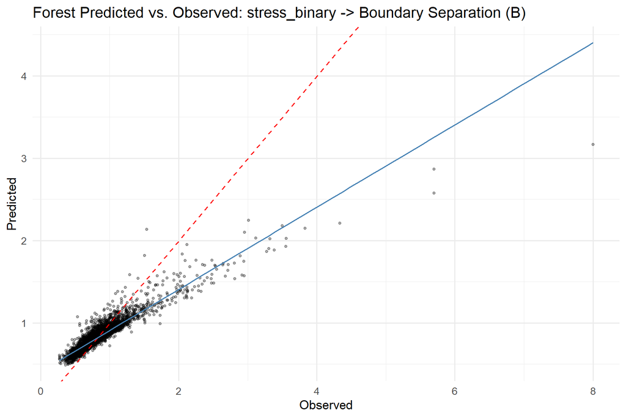

## 2.4 Model Comparison

### 2.4.1 RMSE Comparison (all methods and feature sets)

| Method | Raw | PCA | UMAP |
| --- | --- | --- | --- |
| glmm | 0.3231 | 0.3231 | 0.3224 |
| forest | 0.2976 | 0.3172 | 0.3066 |
| tree | 0.3240 | 0.3240 | 0.3240 |

# 3 Stress State (stress_state)

## 3.1 Dimensionality Reduction

- **PCA components (80% variance, max 5):** 5
- **UMAP components (matching PCA):** 5

### 3.1.1 PCA Component Composition (top 5 correlated variables)

**PC_1**

| Variable | Correlation |
| --- | --- |
| alc_exp_energeticYes | -0.576 |
| alc_exp_better_moodYes | -0.557 |
| alc_exp_sociableYes | -0.547 |
| alc_exp_buzzYes | -0.502 |
| alc_craving | -0.487 |

**PC_2**

| Variable | Correlation |
| --- | --- |
| alc_exp_injuryYes | -0.595 |
| alc_exp_be_rudeYes | -0.593 |
| alc_exp_embarrassedYes | -0.578 |
| alc_exp_nauseous_vomitYes | -0.491 |
| alc_exp_hangoverYes | -0.467 |

**PC_3**

| Variable | Correlation |
| --- | --- |
| locationschool_work | 0.591 |
| alc_today | -0.578 |
| alc_cuenone | 0.569 |
| time_of_dayevening | -0.476 |
| locationhome | -0.459 |

**PC_4**

| Variable | Correlation |
| --- | --- |
| soft_yday | 0.697 |
| soft_today | 0.649 |
| soft_intend | 0.634 |
| soft_craving | 0.489 |
| alc_exp_embarrassedYes | -0.389 |

**PC_5**

| Variable | Correlation |
| --- | --- |
| locationhome | -0.632 |
| social_context_aloneYes | -0.560 |
| social_context_friend_roommateYes | 0.501 |
| social_context_strangerYes | 0.418 |
| locationsomeone_elses_home | 0.372 |

### 3.1.2 UMAP Component Composition (top 5 correlated variables)

**UMAP_1**

| Variable | Correlation |
| --- | --- |
| alc_exp_embarrassedYes | 0.315 |
| alc_exp_be_rudeYes | 0.312 |
| alc_craving | 0.295 |
| alc_intend | 0.252 |
| alc_yday | 0.200 |

**UMAP_2**

| Variable | Correlation |
| --- | --- |
| alc_yday | -0.368 |
| alc_intend | -0.143 |
| alc_exp_embarrassedYes | 0.129 |
| alc_exp_be_rudeYes | 0.126 |
| alc_mot_enhanceYes | -0.116 |

**UMAP_3**

| Variable | Correlation |
| --- | --- |
| alc_yday | -0.339 |
| alc_today | -0.338 |
| soft_craving | 0.164 |
| thirst_state | 0.156 |
| hunger_state | 0.135 |

**UMAP_4**

| Variable | Correlation |
| --- | --- |
| soft_yday | 0.774 |
| soft_today | 0.656 |
| soft_intend | 0.548 |
| soft_craving | 0.287 |
| alc_exp_injuryYes | 0.156 |

**UMAP_5**

| Variable | Correlation |
| --- | --- |
| alc_exp_injuryYes | 0.505 |
| alc_exp_nauseous_vomitYes | 0.361 |
| alc_exp_embarrassedYes | 0.355 |
| alc_exp_be_rudeYes | 0.353 |
| alc_exp_energeticYes | 0.194 |

## 3.2 GLMM Results

### 3.2.1 Raw Features

- **Optimal lambda:** 160 (index 5 of 21)
- **CV RMSE:** 0.3183

**Non-zero coefficients** (focal predictor terms highlighted):

| Term | Estimate | Category |
| --- | --- | --- |
| (Intercept) | 0.8140 | Intercept |
| soft_today | 0.0005 | Covariate main effect |
| time_of_dayevening:stress_state | -0.0176 | Interaction with focal predictor |

- 95 coefficients penalized to zero.*

#### 3.2.1.1 Predicted vs. Observed

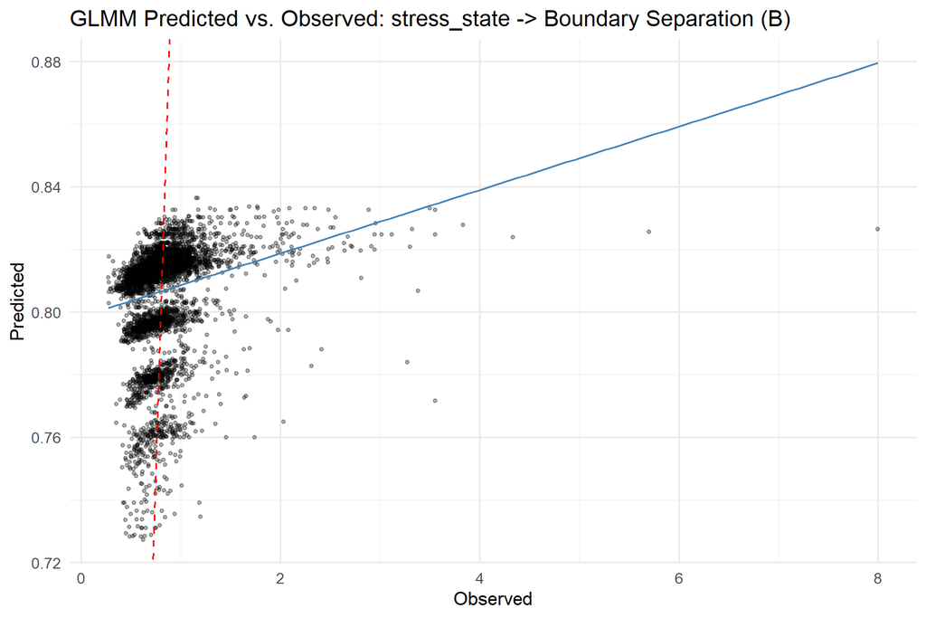

#### 3.2.1.2 Residual Diagnostics

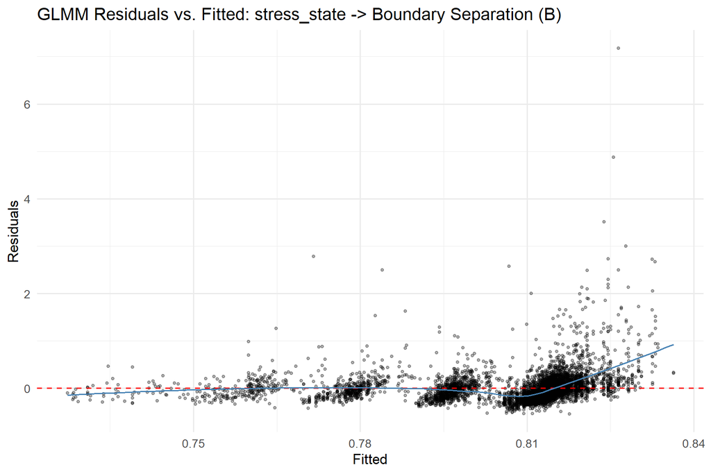

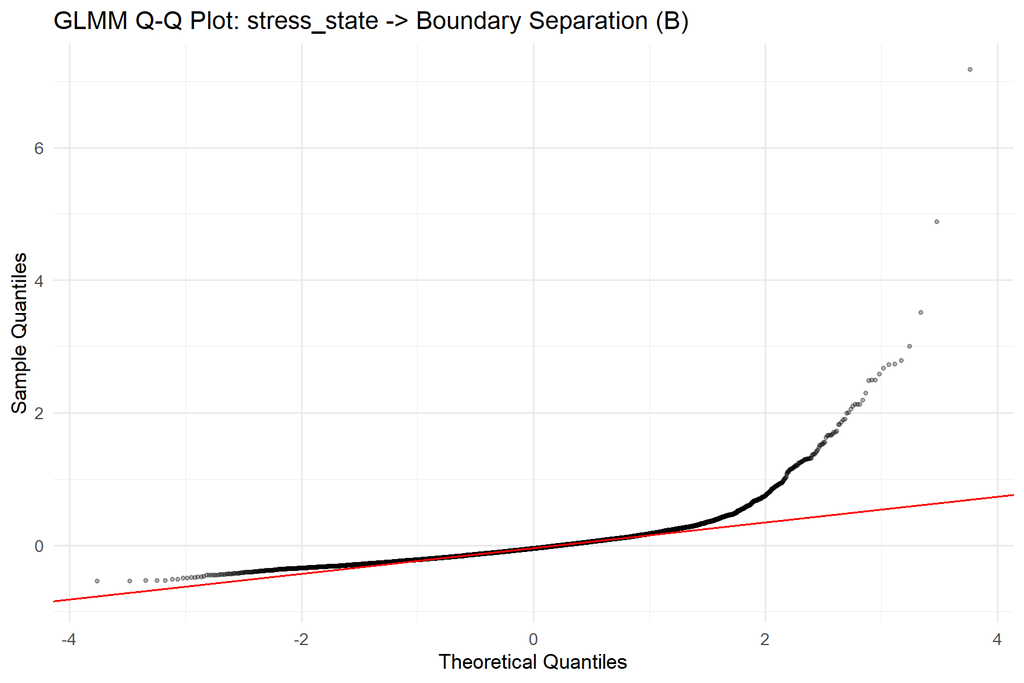

### 3.2.2 PCA Features

- **Optimal lambda:** 170 (index 4 of 21)
- **CV RMSE:** 0.3183

**Non-zero coefficients:**

| Term | Estimate |
| --- | --- |
| (Intercept) | 0.8080 |
| PC_5:stress_state | 0.0025 |

- 10 coefficients penalized to zero.*

### 3.2.3 UMAP Features

- **Optimal lambda:** 100 (index 11 of 21)
- **CV RMSE:** 0.3182

**Non-zero coefficients:**

| Term | Estimate |
| --- | --- |
| (Intercept) | 0.8058 |
| UMAP_1 | 0.0001 |
| UMAP_4 | 0.0115 |
| UMAP_1:stress_state | 0.0083 |
| UMAP_5:stress_state | -0.0017 |

- 7 coefficients penalized to zero.*

## 3.3 Random Forest Results (Raw)

### 3.3.1 Tuning Summary

- **mtry:** 12
- **min.node.size:** 2
- **sample.fraction:** 0.745
- **CV RMSE:** 0.2929

### 3.3.2 Variable Importance (Permutation)

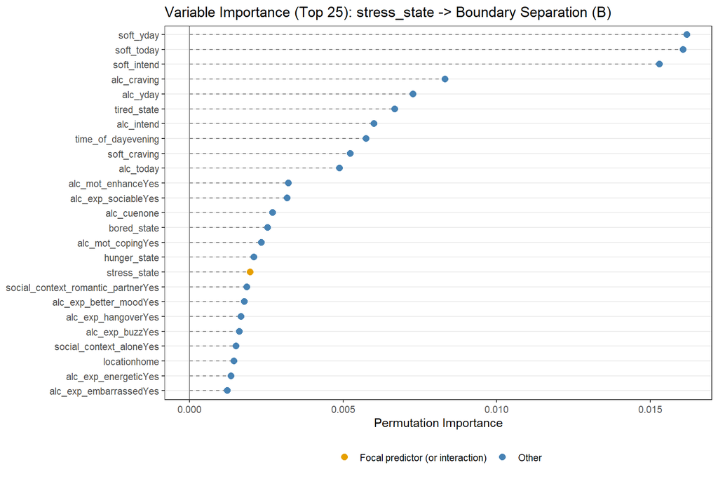

**Full importance ranking:**

| Variable | Importance |
| --- | --- |
| soft_yday | 0.016194 |
| soft_today | 0.016073 |
| soft_intend | 0.015306 |
| alc_craving | 0.008320 |
| alc_yday | 0.007276 |
| tired_state | 0.006688 |
| alc_intend | 0.006004 |
| time_of_dayevening | 0.005755 |
| soft_craving | 0.005237 |
| alc_today | 0.004887 |
| alc_mot_enhanceYes | 0.003216 |
| alc_exp_sociableYes | 0.003172 |
| alc_cuenone | 0.002707 |
| bored_state | 0.002538 |
| alc_mot_copingYes | 0.002335 |
| hunger_state | 0.002100 |
| stress_state | 0.001972 |
| social_context_romantic_partnerYes | 0.001859 |
| alc_exp_better_moodYes | 0.001784 |
| alc_exp_hangoverYes | 0.001672 |
| alc_exp_buzzYes | 0.001627 |
| social_context_aloneYes | 0.001516 |
| locationhome | 0.001443 |
| alc_exp_energeticYes | 0.001356 |
| alc_exp_embarrassedYes | 0.001226 |
| alc_mot_socialYes | 0.001090 |
| alc_exp_be_rudeYes | 0.001033 |
| social_context_familyYes | 0.000973 |
| thirst_state | 0.000942 |
| alc_exp_nauseous_vomitYes | 0.000568 |
| locationoutdoors | 0.000385 |
| social_context_friend_roommateYes | 0.000328 |
| day_of_weekThu | 0.000187 |
| alc_exp_injuryYes | 0.000183 |
| locationschool_work | 0.000146 |
| social_context_coworker_classmateYes | 0.000070 |
| locationsomeone_elses_home | 0.000020 |
| social_context_otherYes | 0.000005 |
| locationrestaurant_cafe | 0.000005 |
| alc_cueindirectly_visible | -0.000019 |
| day_of_weekMon | -0.000059 |
| locationother | -0.000060 |
| day_of_weekTue | -0.000114 |
| social_context_strangerYes | -0.000118 |
| day_of_weekWed | -0.000318 |
| alc_exp_relaxedYes | -0.000322 |
| day_of_weekSun | -0.000602 |
| responsibilityYes | -0.000933 |
| day_of_weekSat | -0.002391 |

### 3.3.3 Partial Dependence Plots

PDP for the focal predictor and the top 5 most important non-interaction covariates.

#### 3.3.3.1 Focal Predictor: stress_state

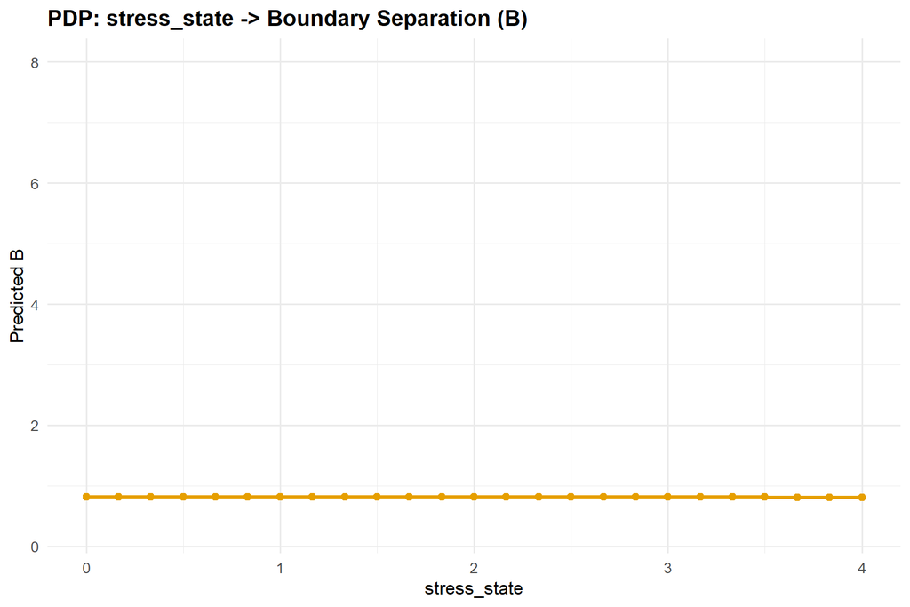

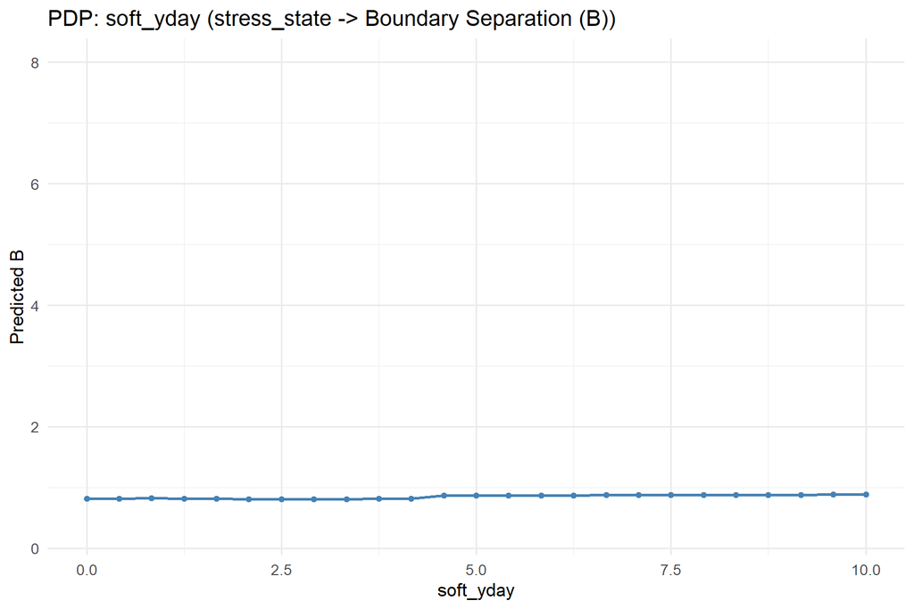

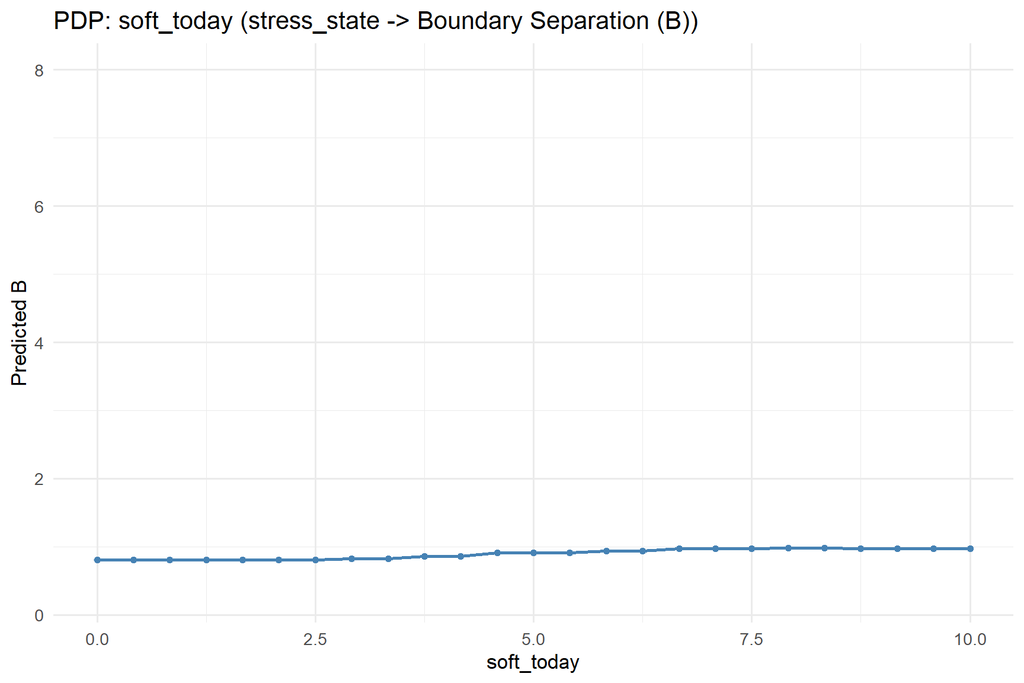

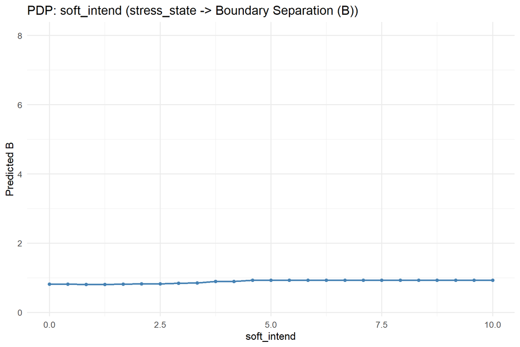

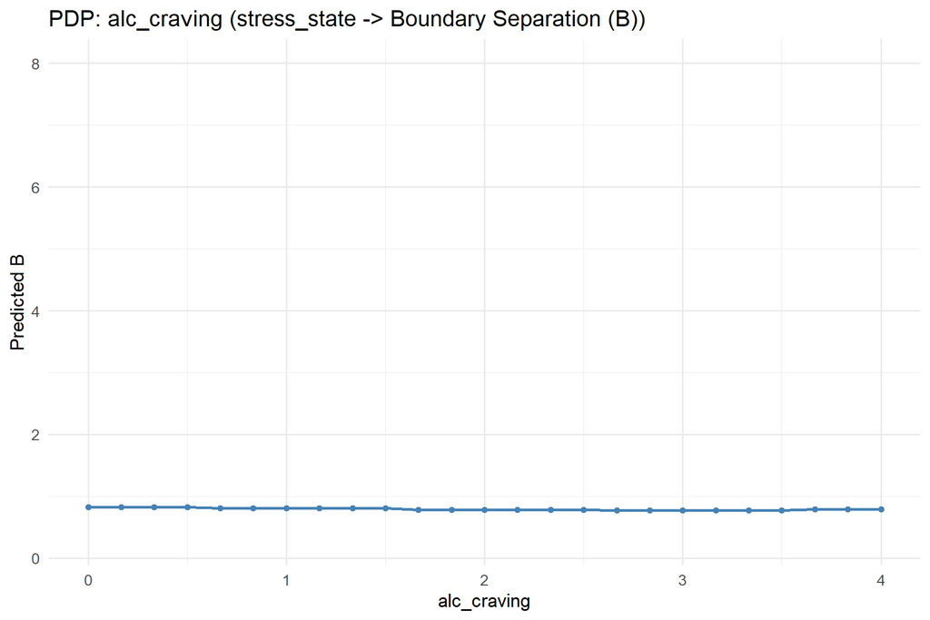

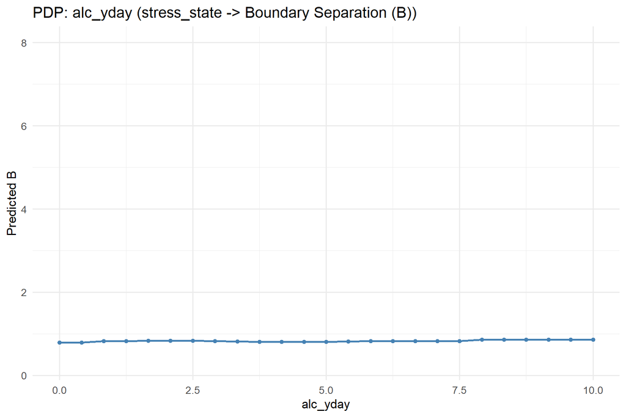

### 3.3.4 Predicted vs. Observed

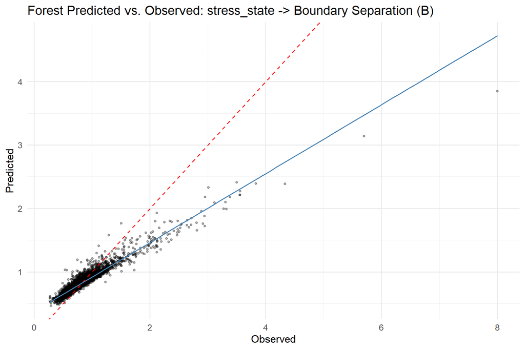

## 3.4 Model Comparison

### 3.4.1 RMSE Comparison (all methods and feature sets)

| Method | Raw | PCA | UMAP |
| --- | --- | --- | --- |
| glmm | 0.3183 | 0.3183 | 0.3182 |
| forest | 0.2929 | 0.3117 | 0.3017 |
| tree | 0.3184 | 0.3192 | 0.3193 |

# 4 Negative Affect State (NA_state)

## 4.1 Dimensionality Reduction

- **PCA components (80% variance, max 5):** 5
- **UMAP components (matching PCA):** 5

### 4.1.1 PCA Component Composition (top 5 correlated variables)

**PC_1**

| Variable | Correlation |
| --- | --- |
| alc_exp_energeticYes | -0.576 |
| alc_exp_better_moodYes | -0.557 |
| alc_exp_sociableYes | -0.547 |
| alc_exp_buzzYes | -0.502 |
| alc_craving | -0.487 |

**PC_2**

| Variable | Correlation |
| --- | --- |
| alc_exp_injuryYes | -0.596 |
| alc_exp_be_rudeYes | -0.594 |
| alc_exp_embarrassedYes | -0.579 |
| alc_exp_nauseous_vomitYes | -0.491 |
| alc_exp_hangoverYes | -0.468 |

**PC_3**

| Variable | Correlation |
| --- | --- |
| locationschool_work | 0.591 |
| alc_today | -0.578 |
| alc_cuenone | 0.569 |
| time_of_dayevening | -0.476 |
| locationhome | -0.457 |

**PC_4**

| Variable | Correlation |
| --- | --- |
| soft_yday | 0.700 |
| soft_today | 0.650 |
| soft_intend | 0.635 |
| soft_craving | 0.488 |
| alc_exp_embarrassedYes | -0.388 |

**PC_5**

| Variable | Correlation |
| --- | --- |
| locationhome | -0.634 |
| social_context_aloneYes | -0.558 |
| social_context_friend_roommateYes | 0.499 |
| social_context_strangerYes | 0.418 |
| locationsomeone_elses_home | 0.371 |

### 4.1.2 UMAP Component Composition (top 5 correlated variables)

**UMAP_1**

| Variable | Correlation |
| --- | --- |
| alc_exp_embarrassedYes | 0.311 |
| alc_exp_be_rudeYes | 0.308 |
| alc_craving | 0.241 |
| alc_intend | 0.176 |
| alc_mot_copingYes | 0.145 |

**UMAP_2**

| Variable | Correlation |
| --- | --- |
| alc_yday | -0.339 |
| soft_yday | 0.151 |
| alc_exp_embarrassedYes | 0.116 |
| alc_exp_be_rudeYes | 0.113 |
| soft_today | 0.109 |

**UMAP_3**

| Variable | Correlation |
| --- | --- |
| alc_yday | 0.463 |
| alc_today | 0.412 |
| alc_intend | 0.244 |
| alc_cuenone | -0.197 |
| responsibilityYes | -0.132 |

**UMAP_4**

| Variable | Correlation |
| --- | --- |
| soft_yday | -0.767 |
| soft_today | -0.657 |
| soft_intend | -0.548 |
| soft_craving | -0.284 |
| alc_exp_injuryYes | -0.149 |

**UMAP_5**

| Variable | Correlation |
| --- | --- |
| alc_exp_injuryYes | -0.507 |
| alc_exp_embarrassedYes | -0.380 |
| alc_exp_be_rudeYes | -0.378 |
| alc_exp_nauseous_vomitYes | -0.351 |
| alc_exp_energeticYes | -0.230 |

## 4.2 GLMM Results

### 4.2.1 Raw Features

- **Optimal lambda:** 120 (index 9 of 21)
- **CV RMSE:** 0.316

**Non-zero coefficients** (focal predictor terms highlighted):

| Term | Estimate | Category |
| --- | --- | --- |
| (Intercept) | 0.8299 | Intercept |
| NA_state | 0.0010 | Focal predictor |
| alc_craving | -0.0137 | Covariate main effect |
| alc_exp_better_moodYes | -0.0119 | Covariate main effect |
| alc_mot_copingYes | -0.0084 | Covariate main effect |
| bored_state | -0.0059 | Covariate main effect |
| soft_today | 0.0053 | Covariate main effect |
| alc_mot_enhanceYes | -0.0039 | Covariate main effect |
| time_of_dayevening:NA_state | -0.0251 | Interaction with focal predictor |
| alc_exp_buzzYes:NA_state | 0.0008 | Interaction with focal predictor |
| soft_today:NA_state | 0.0006 | Interaction with focal predictor |
| locationhome:NA_state | 0.0005 | Interaction with focal predictor |
| social_context_aloneYes:NA_state | 0.0005 | Interaction with focal predictor |
| soft_yday:NA_state | 0.0003 | Interaction with focal predictor |

- 84 coefficients penalized to zero.*

#### 4.2.1.1 Predicted vs. Observed

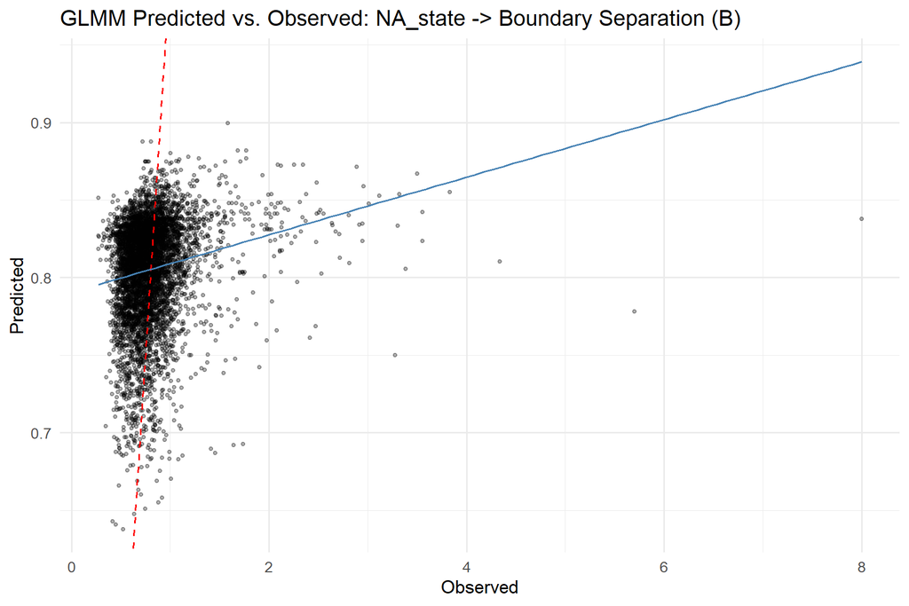

#### 4.2.1.2 Residual Diagnostics

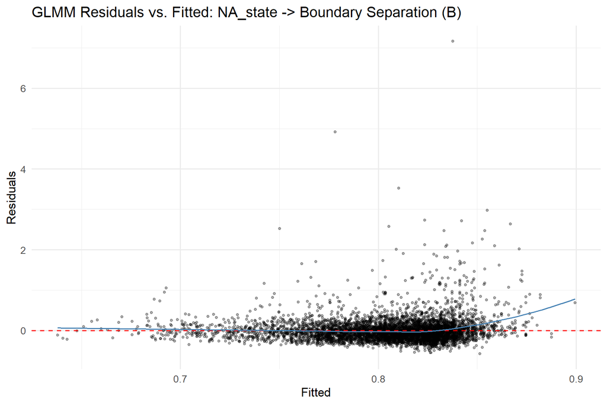

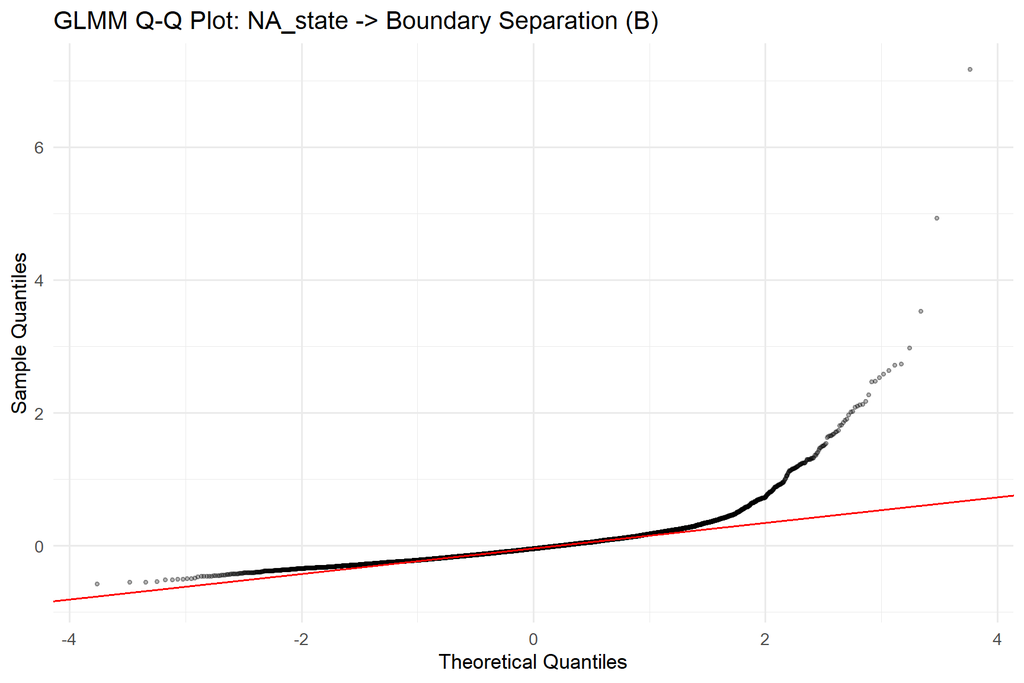

### 4.2.2 PCA Features

- **Optimal lambda:** 120 (index 9 of 21)
- **CV RMSE:** 0.3162

**Non-zero coefficients:**

| Term | Estimate |
| --- | --- |
| (Intercept) | 0.8063 |
| PC_1 | 0.0002 |
| PC_2 | -0.0045 |
| PC_5 | 0.0016 |
| PC_5:NA_state | 0.0061 |

- 7 coefficients penalized to zero.*

### 4.2.3 UMAP Features

- **Optimal lambda:** 70 (index 14 of 21)
- **CV RMSE:** 0.3161

**Non-zero coefficients:**

| Term | Estimate |
| --- | --- |
| (Intercept) | 0.8048 |
| UMAP_1 | 0.0075 |
| UMAP_4 | -0.0059 |
| UMAP_5 | 0.0001 |
| UMAP_1:NA_state | 0.0055 |
| UMAP_4:NA_state | -0.0035 |
| UMAP_5:NA_state | -0.0001 |

- 5 coefficients penalized to zero.*

## 4.3 Random Forest Results (Raw)

### 4.3.1 Tuning Summary

- **mtry:** 14
- **min.node.size:** 4
- **sample.fraction:** 0.704
- **CV RMSE:** 0.2905

### 4.3.2 Variable Importance (Permutation)

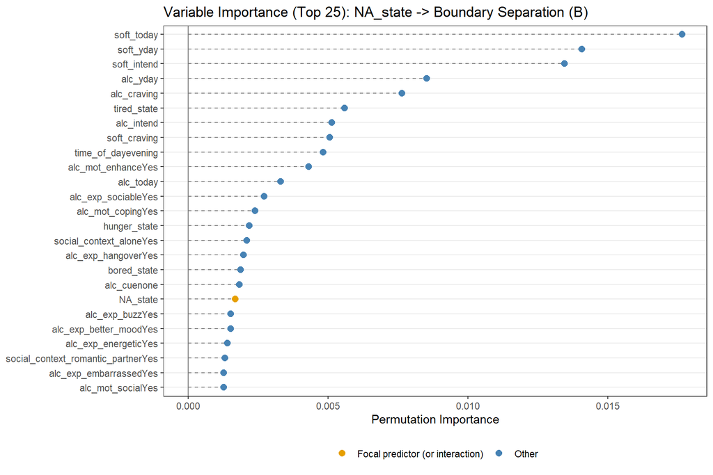

**Full importance ranking:**

| Variable | Importance |
| --- | --- |
| soft_today | 0.017660 |
| soft_yday | 0.014071 |
| soft_intend | 0.013453 |
| alc_yday | 0.008528 |
| alc_craving | 0.007645 |
| tired_state | 0.005590 |
| alc_intend | 0.005140 |
| soft_craving | 0.005055 |
| time_of_dayevening | 0.004820 |
| alc_mot_enhanceYes | 0.004305 |
| alc_today | 0.003298 |
| alc_exp_sociableYes | 0.002713 |
| alc_mot_copingYes | 0.002395 |
| hunger_state | 0.002181 |
| social_context_aloneYes | 0.002089 |
| alc_exp_hangoverYes | 0.001975 |
| bored_state | 0.001865 |
| alc_cuenone | 0.001823 |
| NA_state | 0.001678 |
| alc_exp_buzzYes | 0.001515 |
| alc_exp_better_moodYes | 0.001512 |
| alc_exp_energeticYes | 0.001401 |
| social_context_romantic_partnerYes | 0.001305 |
| alc_exp_embarrassedYes | 0.001274 |
| alc_mot_socialYes | 0.001269 |
| locationhome | 0.001199 |
| alc_exp_be_rudeYes | 0.000902 |
| social_context_familyYes | 0.000867 |
| thirst_state | 0.000835 |
| alc_exp_nauseous_vomitYes | 0.000382 |
| locationschool_work | 0.000357 |
| alc_exp_relaxedYes | 0.000205 |
| social_context_friend_roommateYes | 0.000200 |
| day_of_weekMon | 0.000091 |
| alc_exp_injuryYes | 0.000079 |
| locationother | 0.000078 |
| locationsomeone_elses_home | 0.000050 |
| locationoutdoors | 0.000049 |
| social_context_coworker_classmateYes | 0.000030 |
| alc_cueindirectly_visible | 0.000016 |
| social_context_otherYes | 0.000008 |
| locationrestaurant_cafe | 0.000005 |
| social_context_strangerYes | -0.000001 |
| day_of_weekThu | -0.000142 |
| day_of_weekTue | -0.000306 |
| day_of_weekWed | -0.000382 |
| day_of_weekSun | -0.000383 |
| responsibilityYes | -0.000509 |
| day_of_weekSat | -0.001329 |

### 4.3.3 Partial Dependence Plots

PDP for the focal predictor and the top 5 most important non-interaction covariates.

#### 4.3.3.1 Focal Predictor: NA_state

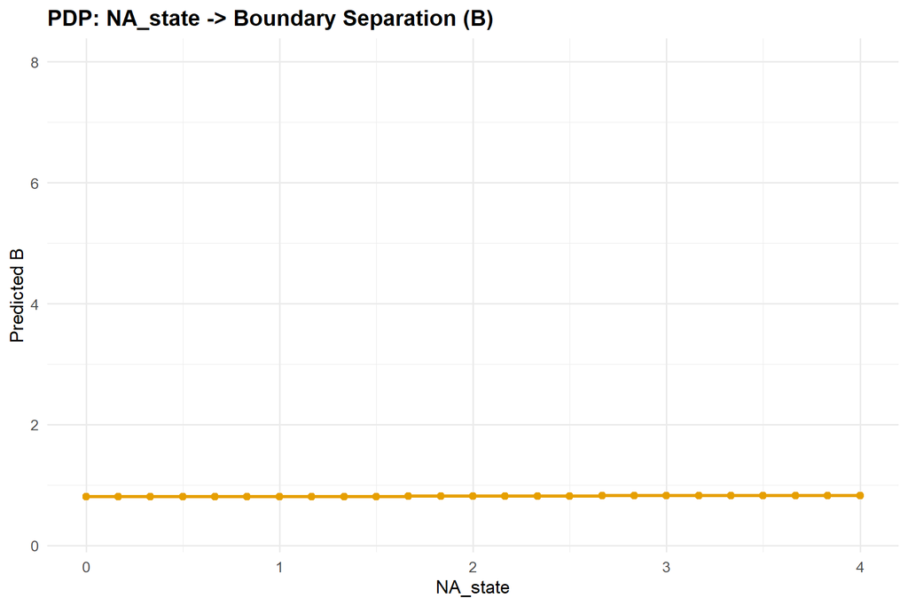

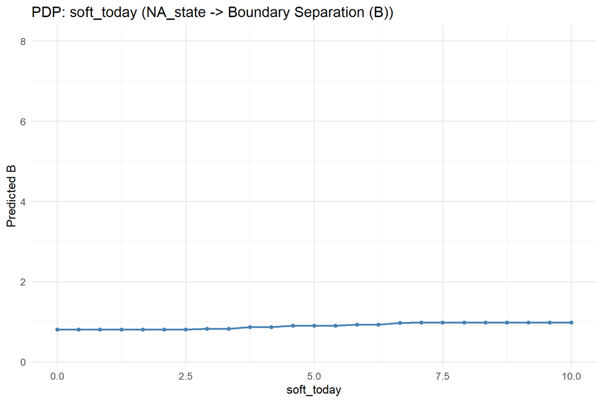

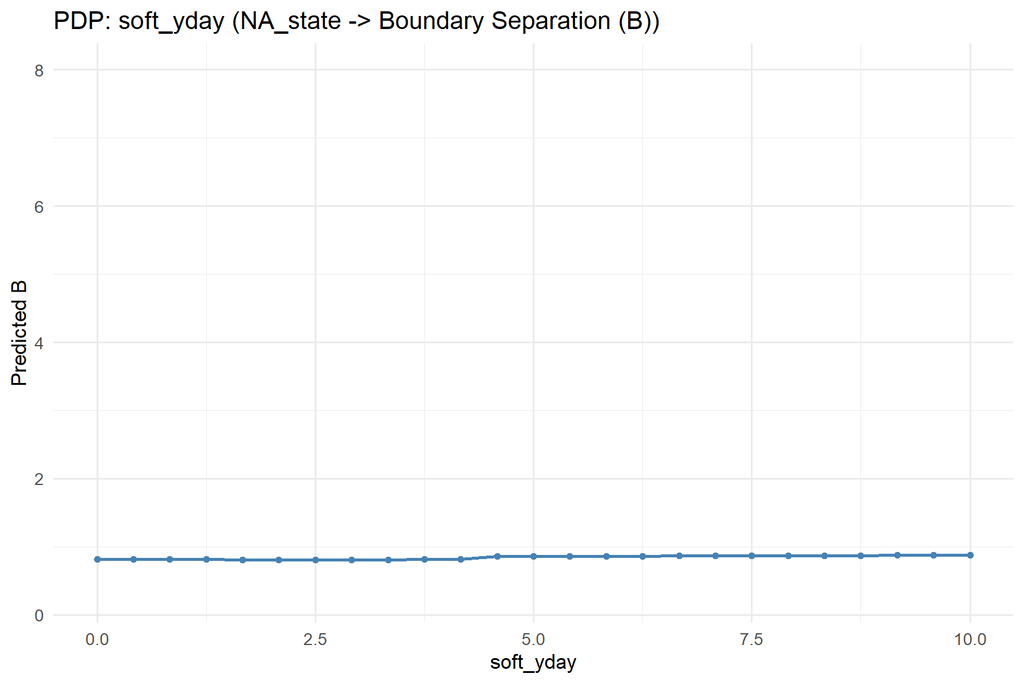

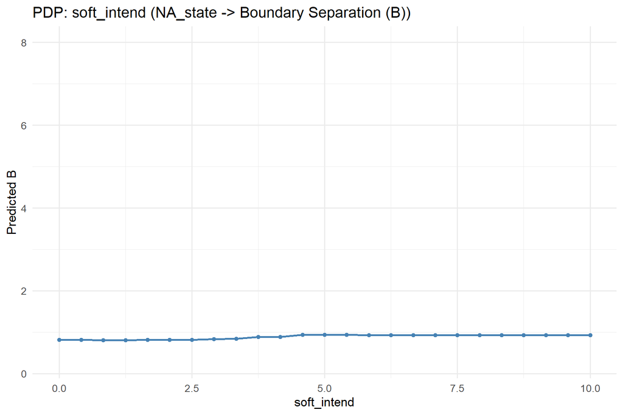

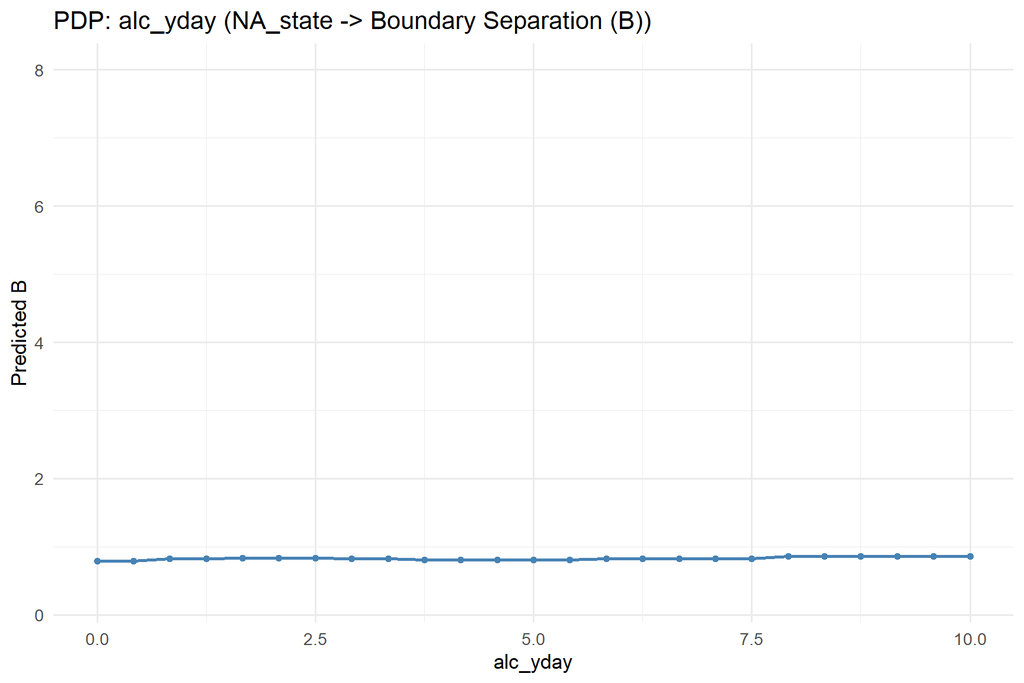

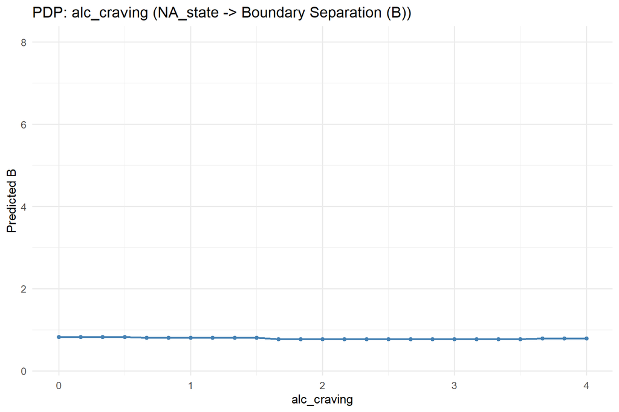